# Notebook 10

## MLE

Let’s simulate some data from an exponential distribution with lambda equal to 4. Here’s a single sample of 50 observations:

```r
x <- rexp(50, rate = 1/4)
x
```

```
##  [1]  3.0207273  4.7265711  0.5828269  0.5591810  1.7442745 11.5798741
##  [7]  4.9182482  2.1587314  3.8262700  0.5881840  5.5629405  3.0481194
## [13]  4.9504142 17.6957369  4.2181727  4.1409758  7.5041407  2.6189865
## [19]  1.3477339  2.3539189  9.4580610  2.5675704  1.1764816  2.2634621
## [25]  0.4242905  0.2377566  2.3148499 15.8357314  4.6932484  3.9872518
## [31]  5.7411414  0.1490741  1.2960406  5.2818717  0.8140414  4.0909035
## [37]  1.2069637  2.9008572  3.0061708  0.9401098  4.3195245  4.1129876
## [43]  5.1690466  5.0124214  2.2185656  1.2051320  5.1724986  3.9782232
## [49]  2.0566972  8.0313296
```

Estimating the mean is not particularly interesting, as it is the same whether we use the sample mean of the MLE. The variance is a different story. We have two options: the MLE (squared mean) and the sample variance (Sx^2). Note that the theoretical variance should be 16.

```r
sprintf("MLE Variance: %02.02f, Sample Variance: %02.02f", mean(x)^2, var(x))
```

```
## [1] "MLE Variance: 15.49, Sample Variance: 12.72"
```

The specific values will change each time we run the code, but you should see that there is (usually) a noticeable difference between the two estimators. Let’s run a simulation to see what happens in the long-run:

```r
N <- 1e5
mle <- rep(NA, N)
svar <- rep(NA, N)
for (j in seq_len(N))
{
  x <- rexp(50, rate = 1/4)
  mle[j] <- mean(x)^2
  svar[j] <- var(x)
}
```

Here is the empirical bias of the sample variance (recall that it has theoretical value of zero):

```r
mean(svar - 16)
```

```
## [1] 0.0161362
```

Not so bad. What about the empirical bias of the MLE? Recall that this might not be theoretically equal to zero for non infinite sample size:

```r
mean(mle - 16)
```

```
## [1] 0.3335618
```

Okay, so the bias is not huge but it is many times larger than the sample variance. Is the MLE a terrible choice here? Well, not really. Let’s look at the variance of the two estimators (note that these are the variances of the estimators of the variance):

```r
sprintf("Var of MLE: %02.02f, Var of S_X^2: %02.02f", var(mle), var(svar))
```

```
## [1] "Var of MLE: 21.52, Var of S_X^2: 41.04"
```

```r
sprintf(
  "Avg. Dist MLE: %02.02f, Avg. Dist S_X^2: %02.02f",
  mean(abs(mle - 16)), mean(abs(svar - 16))
)
```

```
## [1] "Avg. Dist MLE: 3.63, Avg. Dist S_X^2: 4.85"
```

A related metric is called the root mean squared error, or RMSE, which we can describe as follows:

```r
sprintf(
  "RMSE MLE: %02.02f, RMSE S_X^2: %02.02f",
  sqrt(mean((mle - 16)**2)), sqrt(mean(abs(svar - 16)**2))
)
```

```
## [1] "RMSE MLE: 4.65, RMSE S_X^2: 6.41"
```

So, we see that using these metrics the MLE has a better risk at the expense of being unbiased.

## Likelihood Ratio Test

Let’s do another simulation with the exponential distribution, calculating the value of Lambda for each sample:

```r
N <- 1e5
lstat <- rep(NA, N)
for (j in seq_len(N))
{
  lambda <- 4
  x <- rexp(50, rate = 1/lambda)
  lstat[j] <- -2 * (sum(x * log(lambda) - lambda) - sum(x*log(mean(x)) - mean(x)))
}
```

What does the distribution of the test statistic look like?

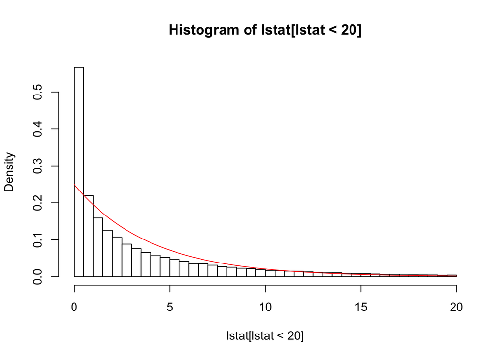

```r
hist(lstat[lstat < 20], breaks = 50, probability = TRUE, col = "white")
curve(dexp(x, rate = 1/lambda),
      from = min(lstat), to = 20, add = TRUE, col = "red")
```

No, it’s not a perfect chi-squared, but you can see that it is approximately one, and would likely work relatively well for constructing a rejection region.